# COVID risk data source comparison

```
## Please enter password in TK window (Alt+Tab)
```

### Data sources:

- NHS 111 queries with suspect covid disposition Resolution: Postcode
- Primary care - confirmed and suspect cases STP
- UK linelist - confirmed cases LTLA
- A&E attendances (currently total only, not covid specific) STP
- ONS covid-related deaths (mentioned or underlying) LTLA
- Model-predicted cases NHS region
- Zoe symptom tracker LTLA

Proxy outcome: No. reported outbreaks in care homes per day/LTLA.

## 111 calls/online reports

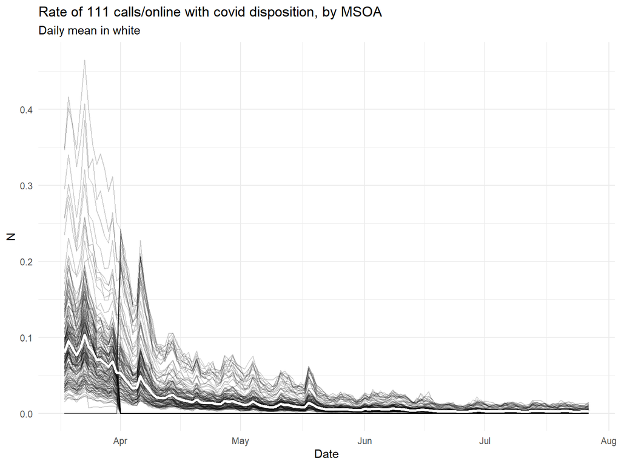

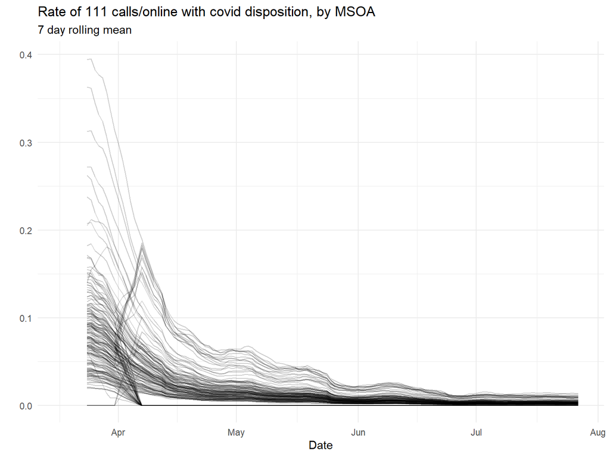

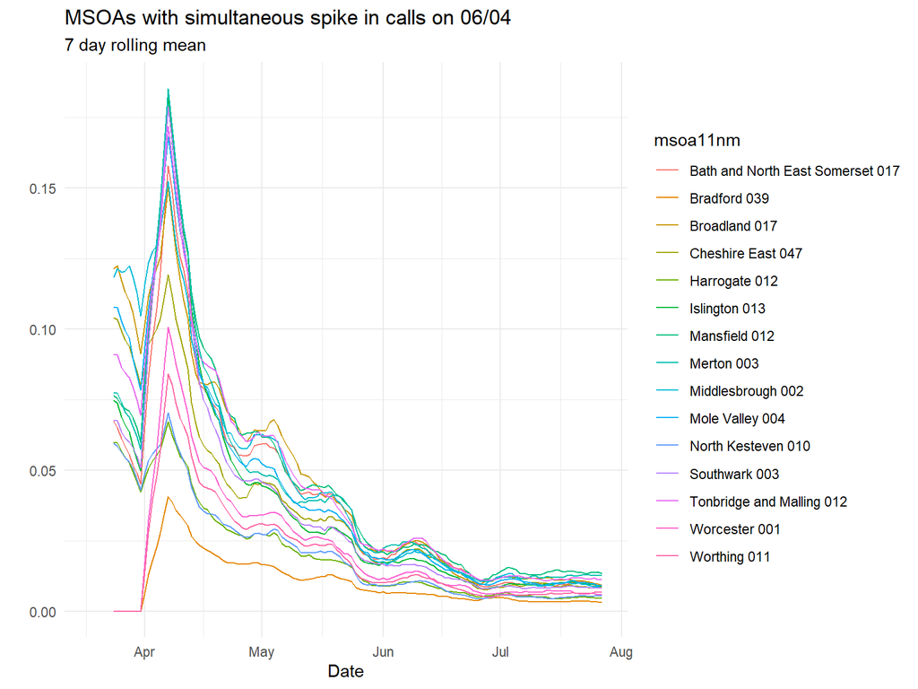

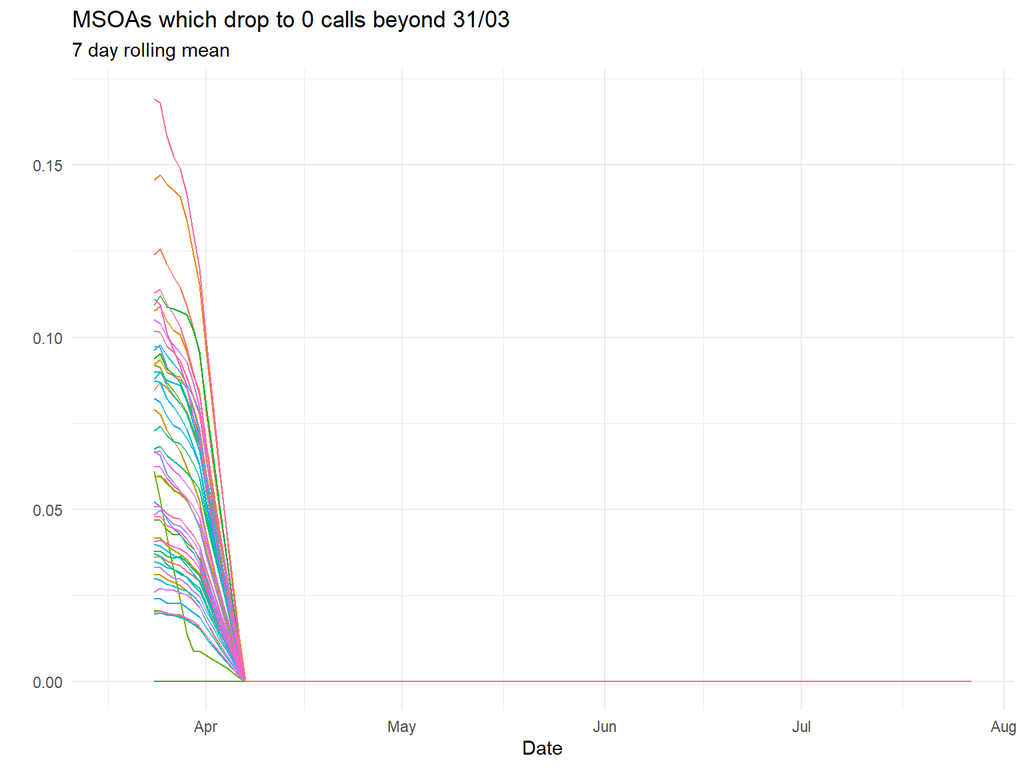

Subset of MSOAs which all spike on 06/04 for rolling mean (n = 15) - maybe data missing for first few weeks? Appear randomly distributed, not within a particular area. Also another subgroup for which data stop at end of March (n = 49).

## UK Linelist (confirmed cases, pillar 1+2)

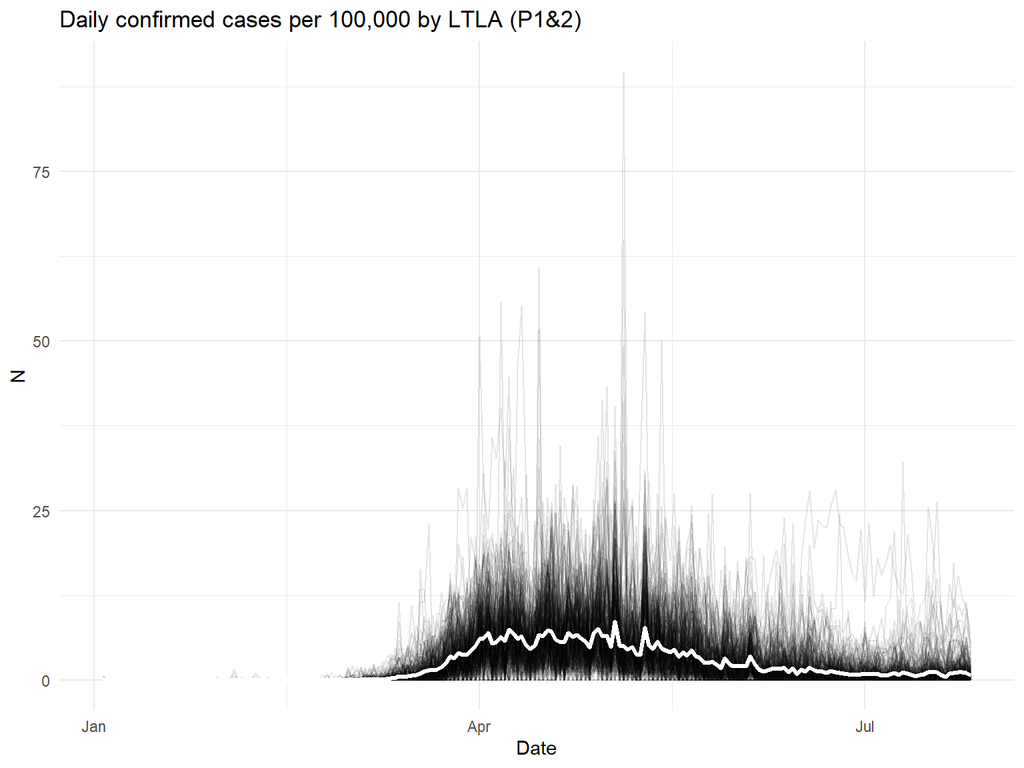

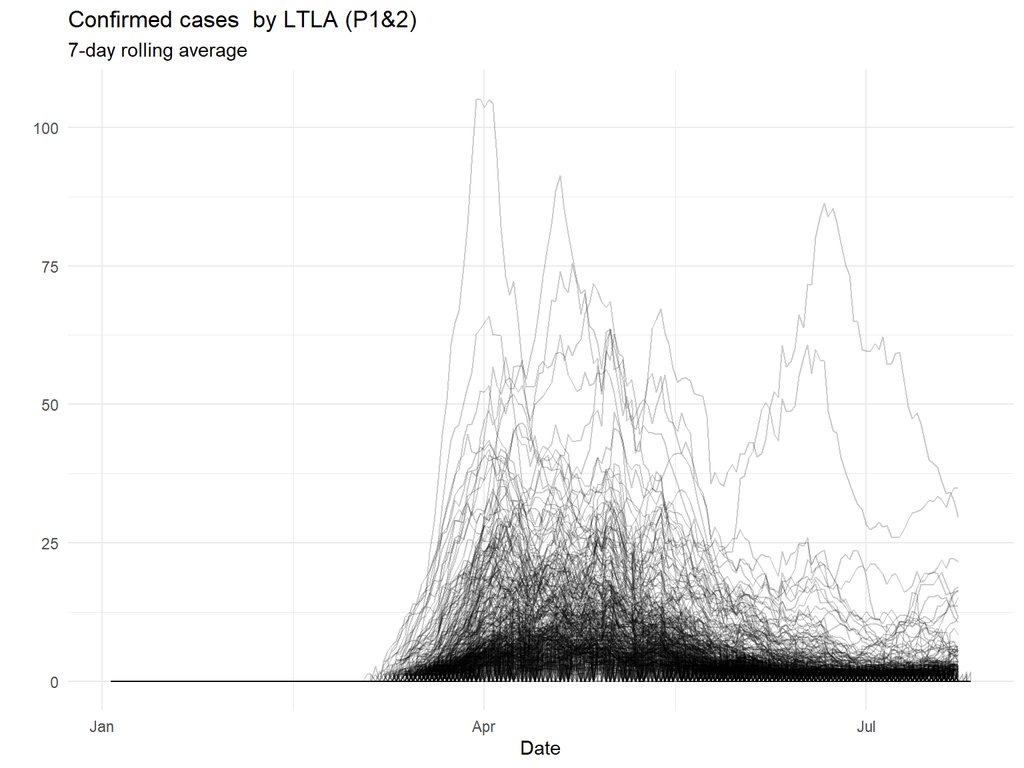

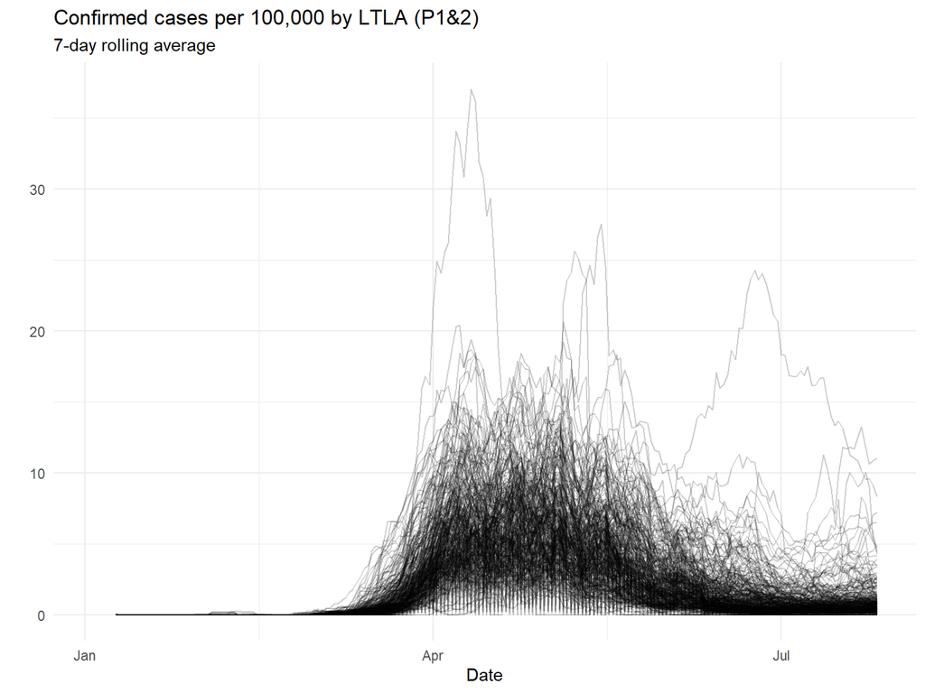

Two outlying series in absolute counts are **Leicester** and **Sheffield**.

## ONS Covid-related deaths

Including cases with covid recorded as an underlying cause of death or mentioned on death certificate.

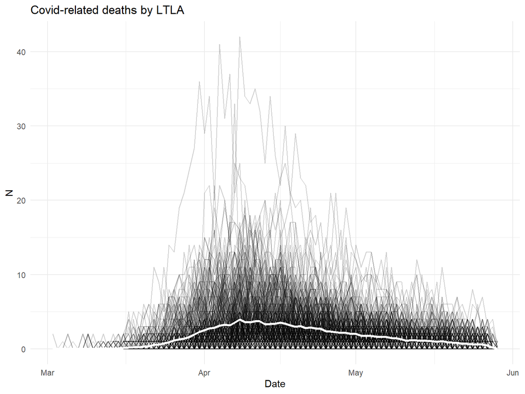

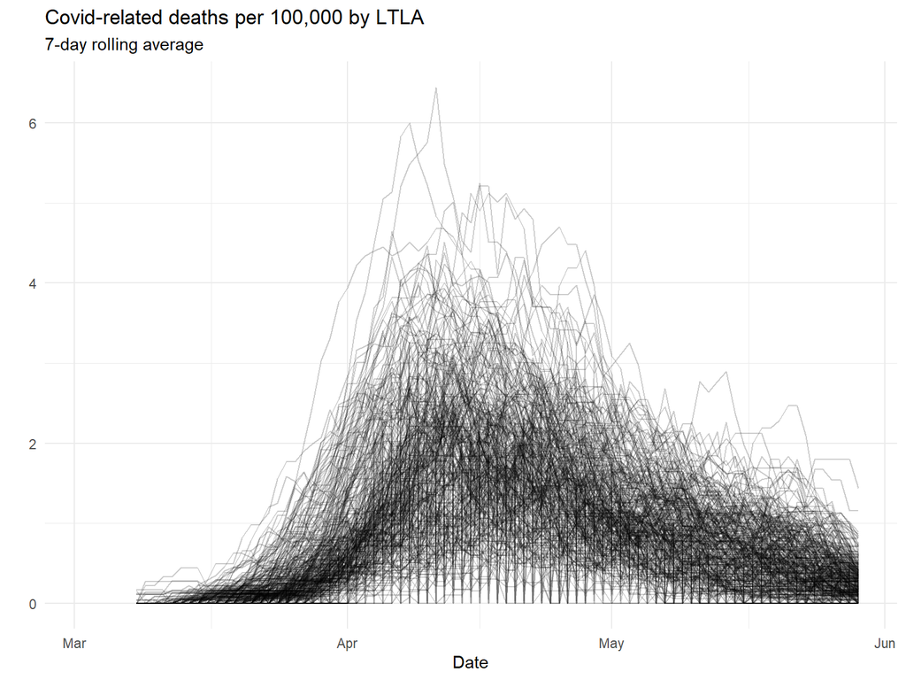

## Compare 111/linelist/deaths

In total over England.

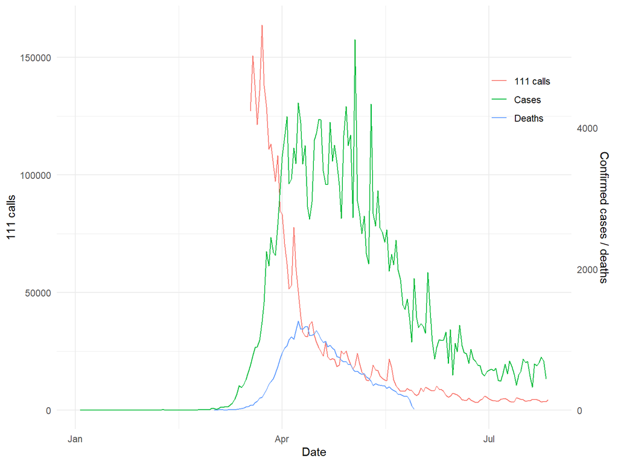

## Model-predicted cases

From big transmission model - available by NHS region and 5-year age bands. Originally fitted to death data. Don’t include care homes.

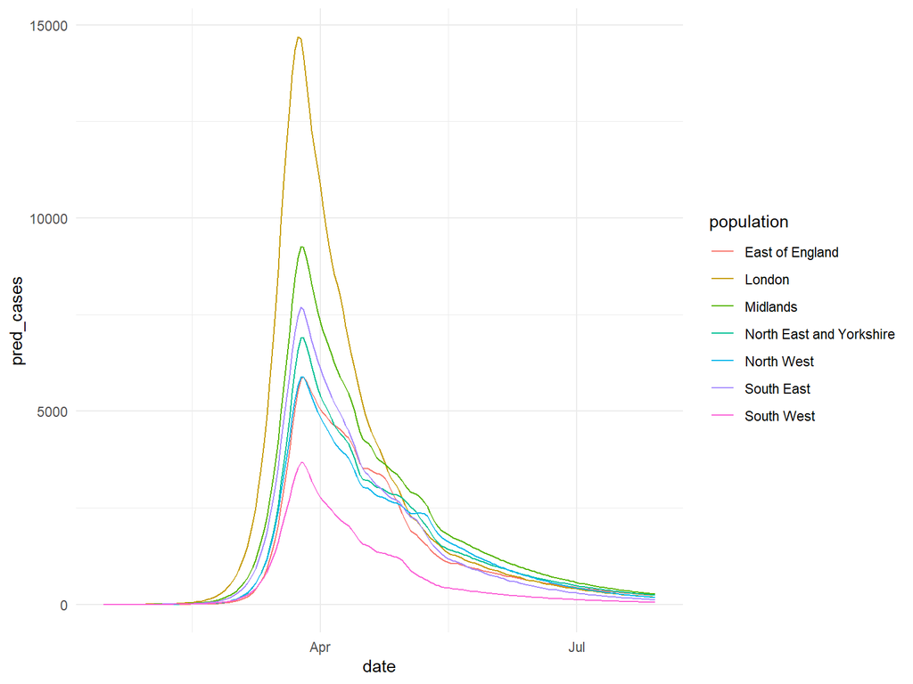

### Compare to ONS deaths by NHS region:

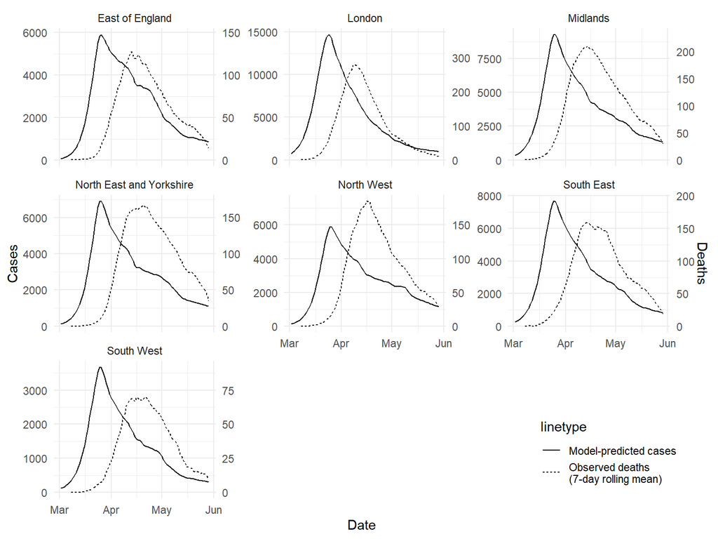

Approx 3 week lag between predicted case peak and death peak.

### Compare to 111 calls by NHS region:

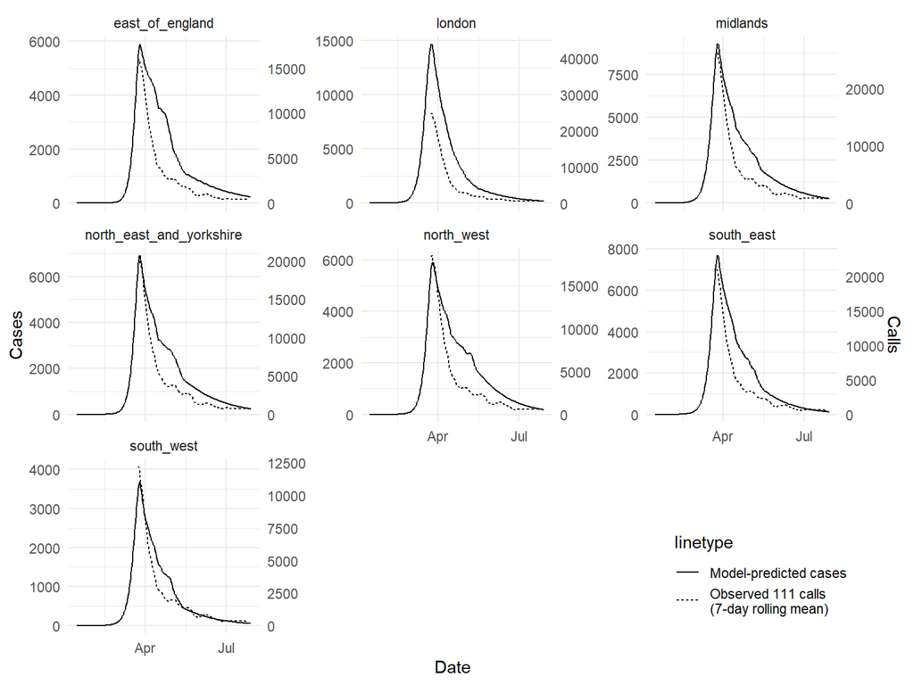

### Compare to confirmed cases from UK LL:

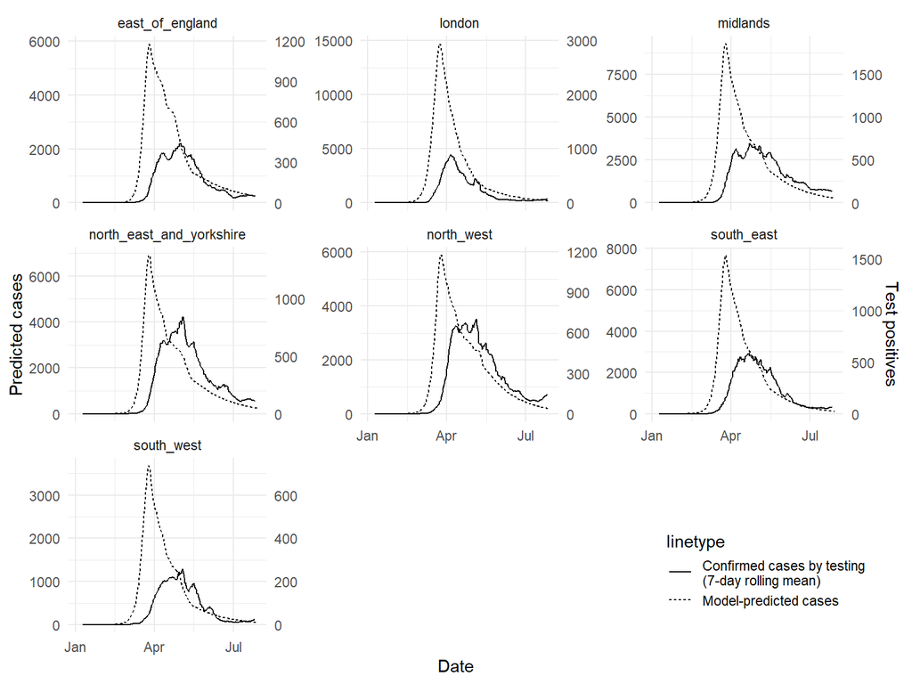

Approx 4 week lag. Model predicts cases at point of infection but UKLL recorded by date of lab report, so lag could be related to symptom onset/testing delay.

## Opensafely EHR data

- Coverage of GPs registered under TPP - ~50% population but distributed unevenly across country.
- A&E data reflect total attendances and only available up to 17/04.
- Death data include covid-mentioned?

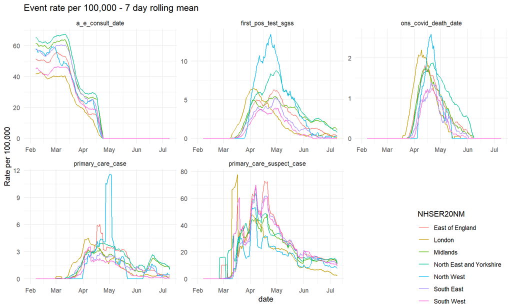

What are the block spikes? E.g. primary care cases beginning of May. Just an artifact of rolling mean being influenced by high values?

### Compare with model predictions:

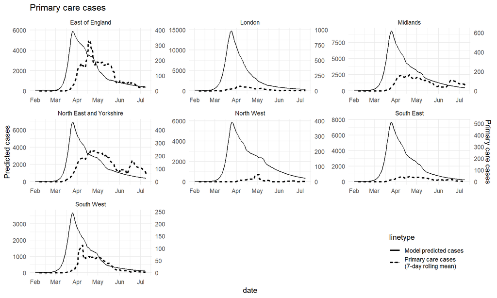

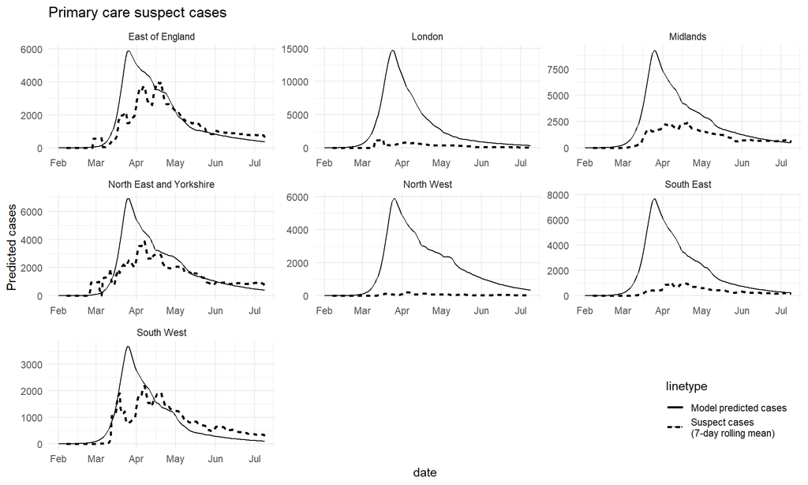

### Compare with calls:

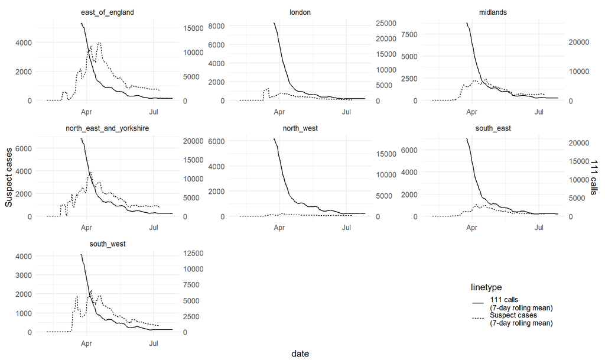

### Compare two death sources

Highlights the coverage of TPP. Second possible source of difference in that the covid death indicator in OS may include only cases with covid as underlying cause of death.

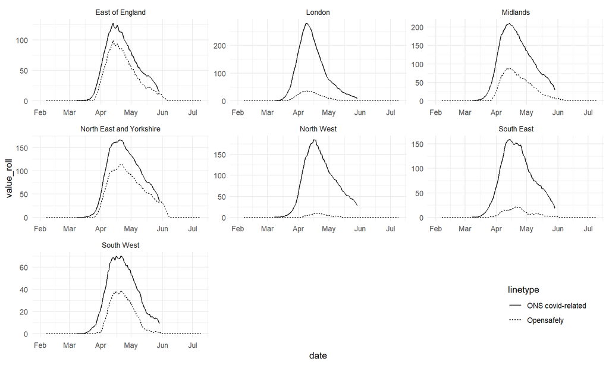

## Zoe symptom tracker data

Estimated incidence of newly symptomatic and prevalence of ongoing cases scaled up to population level from number of responding users.

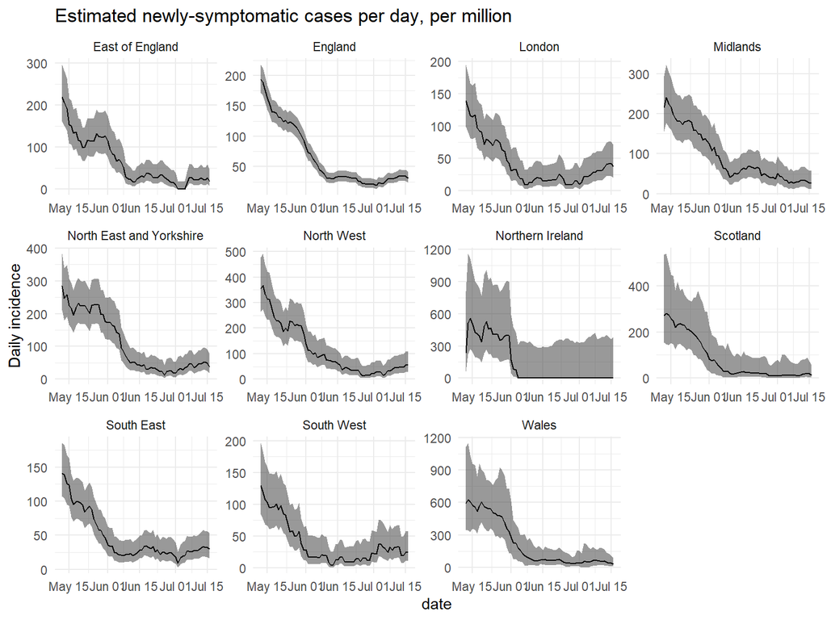

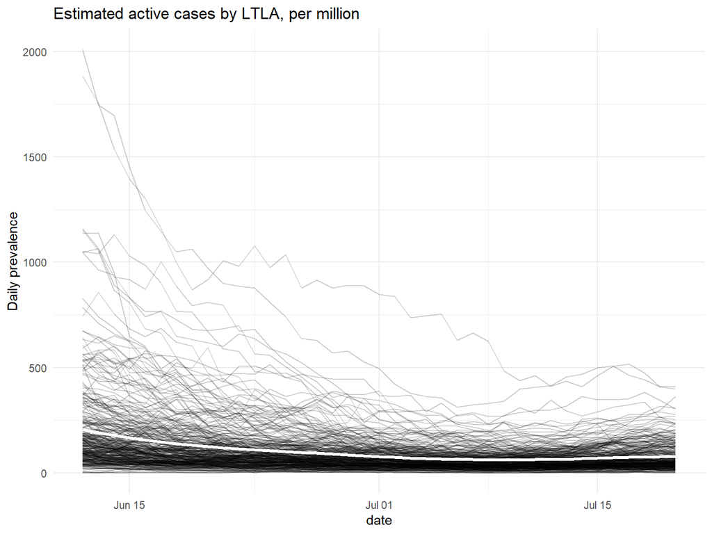

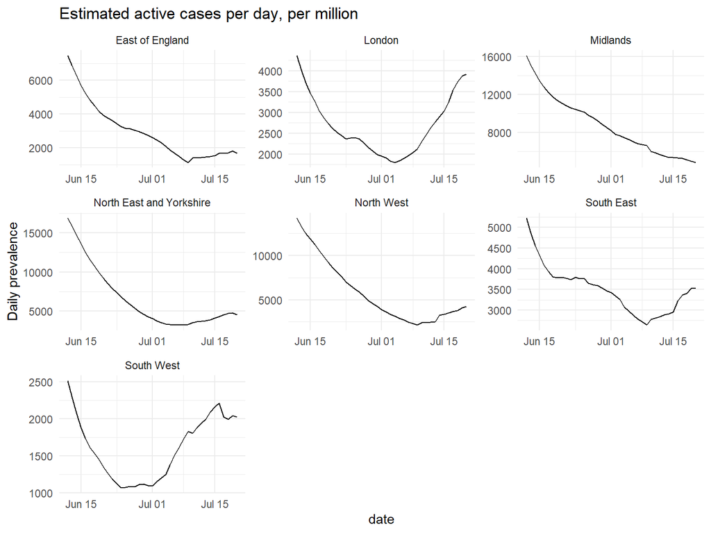

## Reported care home outbreaks

West midlands and Yorkshire peaked slighly later.

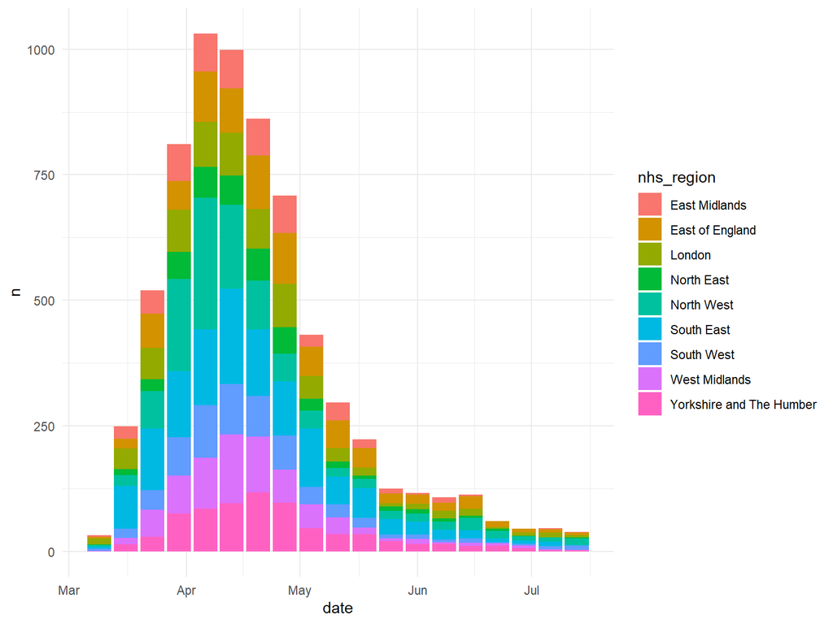

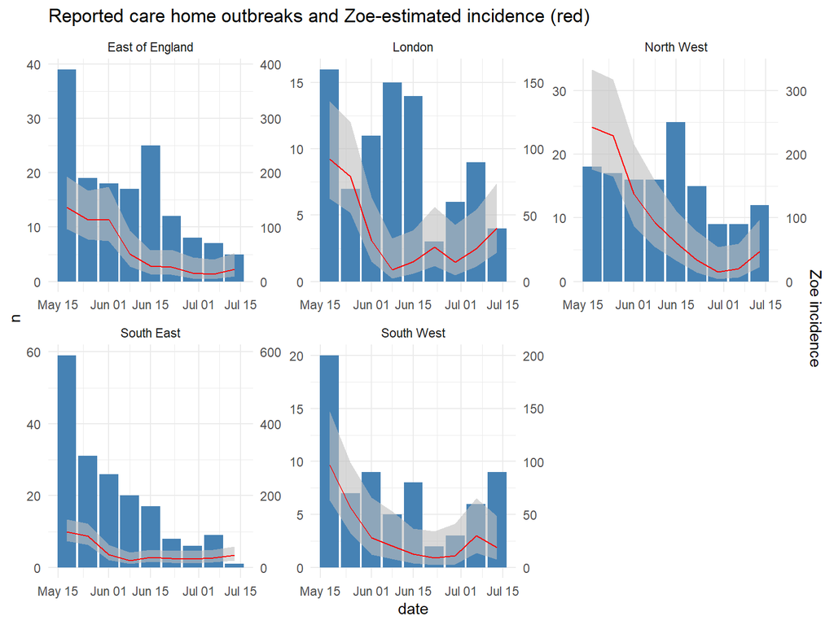

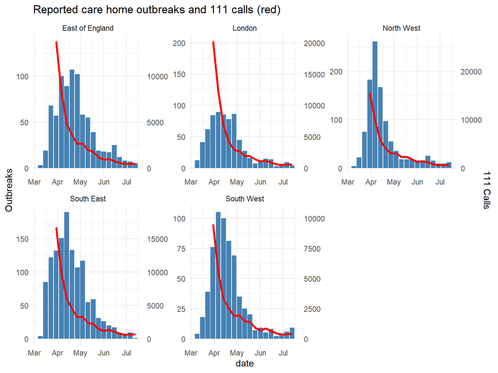

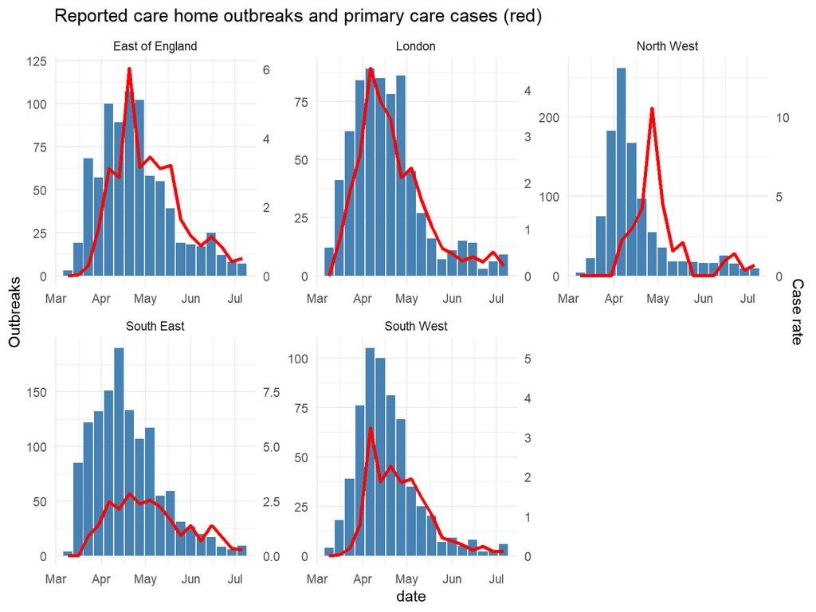

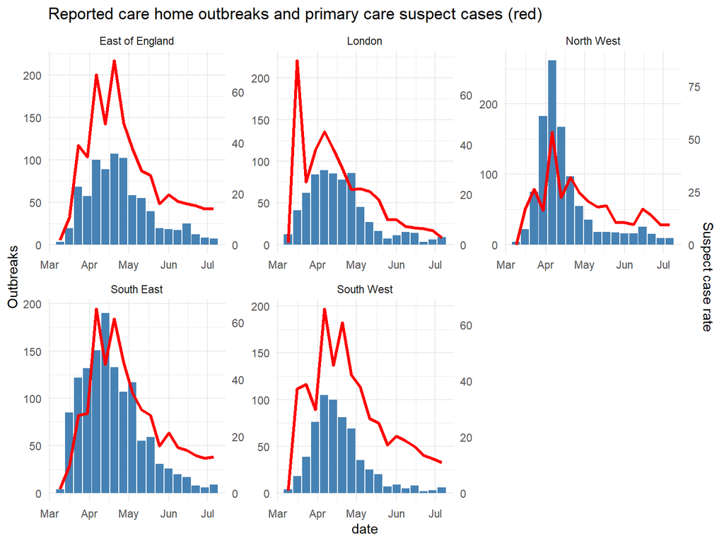